# Deep Learning

## Assignment 2

Previously in `1_notmnist.ipynb`, we created a pickle with formatted datasets for training, development and testing on the [notMNIST dataset](http://yaroslavvb.blogspot.com/2011/09/notmnist-dataset.html).

The goal of this assignment is to progressively train deeper and more accurate models using TensorFlow.

```python
# These are all the modules we'll be using later. Make sure you can import them
# before proceeding further.
from __future__ import print_function
import numpy as np
import tensorflow as tf
from six.moves import cPickle as pickle
from six.moves import range
```

First reload the data we generated in `1_notmnist.ipynb`.

```python
pickle_file = 'notMNIST.pickle'

with open(pickle_file, 'rb') as f:
    save = pickle.load(f)
    train_dataset = save['train_dataset']
    train_labels = save['train_labels']
    valid_dataset = save['valid_dataset']
    valid_labels = save['valid_labels']
    test_dataset = save['test_dataset']
    test_labels = save['test_labels']
    del save  # hint to help gc free up memory
    print('Training set', train_dataset.shape, train_labels.shape)
    print('Validation set', valid_dataset.shape, valid_labels.shape)
    print('Test set', test_dataset.shape, test_labels.shape)
```

```
Training set (200000, 28, 28) (200000,)
Validation set (10000, 28, 28) (10000,)
Test set (10000, 28, 28) (10000,)
```

Reformat into a shape that's more adapted to the models we're going to train:

- data as a flat matrix,
- labels as float 1-hot encodings.

```python
image_size = 28
num_labels = 10

def reformat(dataset, labels):
    dataset = dataset.reshape((-1, image_size * image_size)).astype(np.float32)
    # Map 0 to [1.0, 0.0, 0.0 ...], 1 to [0.0, 1.0, 0.0 ...]
    labels = (np.arange(num_labels) == labels[:,None]).astype(np.float32)
    return dataset, labels
train_dataset, train_labels = reformat(train_dataset, train_labels)
valid_dataset, valid_labels = reformat(valid_dataset, valid_labels)
test_dataset, test_labels = reformat(test_dataset, test_labels)
print('Training set', train_dataset.shape, train_labels.shape)
print('Validation set', valid_dataset.shape, valid_labels.shape)
print('Test set', test_dataset.shape, test_labels.shape)
```

```
Training set (200000, 784) (200000, 10)
Validation set (10000, 784) (10000, 10)
Test set (10000, 784) (10000, 10)
```

```python
train_labels[0]
```

```
array([ 0.,  0.,  0.,  0.,  1.,  0.,  0.,  0.,  0.,  0.], dtype=float32)
```

TensorFlow works like this:

- First you describe the computation that you want to see performed: what the inputs, the variables, and the operations look like. These get created as nodes over a computation graph. This description is all contained within the block below:

  ```
  with graph.as_default():
      ...
  ```

- Then you can run the operations on this graph as many times as you want by calling `session.run()`, providing it outputs to fetch from the graph that get returned. This runtime operation is all contained in the block below:

  ```
  with tf.Session(graph=graph) as session:
      ...
  ```

Let's load all the data into TensorFlow and build the computation graph corresponding to our training:

```python
# With gradient descent training, even this much data is prohibitive.
# Subset the training data for faster turnaround.
train_subset = 10000

graph = tf.Graph()
with graph.as_default():

    # Input data.
    # Load the training, validation and test data into constants that are
    # attached to the graph.
    tf_train_dataset = tf.constant(train_dataset[:train_subset, :])
    tf_train_labels = tf.constant(train_labels[:train_subset])
    tf_valid_dataset = tf.constant(valid_dataset)
    tf_test_dataset = tf.constant(test_dataset)

    # Variables.
    # These are the parameters that we are going to be training. The weight
    # matrix will be initialized using random values following a (truncated)
    # normal distribution. The biases get initialized to zero.
    weights = tf.Variable(
    tf.truncated_normal([image_size * image_size, num_labels]))
    biases = tf.Variable(tf.zeros([num_labels]))

    # Training computation.
    # We multiply the inputs with the weight matrix, and add biases. We compute
    # the softmax and cross-entropy (it's one operation in TensorFlow, because
    # it's very common, and it can be optimized). We take the average of this
    # cross-entropy across all training examples: that's our loss.
    logits = tf.matmul(tf_train_dataset, weights) + biases
    loss = tf.reduce_mean(tf.nn.softmax_cross_entropy_with_logits(logits, tf_train_labels))

    # Optimizer.
    # We are going to find the minimum of this loss using gradient descent.
    optimizer = tf.train.GradientDescentOptimizer(0.5).minimize(loss)

    # Predictions for the training, validation, and test data.
    # These are not part of training, but merely here so that we can report
    # accuracy figures as we train.
    train_prediction = tf.nn.softmax(logits)
    valid_prediction = tf.nn.softmax(tf.matmul(tf_valid_dataset, weights) + biases)
    test_prediction = tf.nn.softmax(tf.matmul(tf_test_dataset, weights) + biases)
```

Let's run this computation and iterate:

```python
%matplotlib inline
import matplotlib.pyplot as plt

V_accur_list = [] #verification accuracy list
step_list = [] # step number list
cost_list = []
```

```python
num_steps = 801

def accuracy(predictions, labels):
    return (100.0 * np.sum(np.argmax(predictions, 1) == np.argmax(labels, 1)) / predictions.shape[0])

with tf.Session(graph=graph) as session:
    # This is a one-time operation which ensures the parameters get initialized as
    # we described in the graph: random weights for the matrix, zeros for the
    # biases.
    tf.initialize_all_variables().run()
    print('Initialized')
    for step in range(num_steps):
        # Run the computations. We tell .run() that we want to run the optimizer,
        # and get the loss value and the training predictions returned as numpy
        # arrays.
        _, l, predictions = session.run([optimizer, loss, train_prediction])
        if (step % 10 == 0):
            cost_list.append(l)
            step_list.append(step)
            print('Loss at step %d: %f' % (step, l))
            print('Training accuracy: %.1f%%' % accuracy(
            predictions, train_labels[:train_subset, :]))
            # Calling .eval() on valid_prediction is basically like calling run(), but
            # just to get that one numpy array. Note that it recomputes all its graph
            # dependencies.
            valid_accuracy = accuracy(valid_prediction.eval(), valid_labels)
            V_accur_list.append(valid_accuracy)
            print('Validation accuracy: %.1f%%' % valid_accuracy)
    test_accuracy = accuracy(test_prediction.eval(), test_labels)
    print('Test accuracy: %.1f%%' % test_accuracy)
    #This line below allows for taking the predictions to a pandas dataframe and eventually a heatmap/confusion matrix
    pred = test_prediction.eval()
```

```
Initialized
Loss at step 0: 18.505116
Training accuracy: 6.1%
Validation accuracy: 7.4%
Loss at step 10: 6.276209
Training accuracy: 35.8%
Validation accuracy: 38.0%
Loss at step 20: 4.314642
Training accuracy: 51.7%
Validation accuracy: 51.9%
Loss at step 30: 3.624284
Training accuracy: 58.4%
Validation accuracy: 59.3%
Loss at step 40: 3.261755
Training accuracy: 62.3%
Validation accuracy: 63.0%
Loss at step 50: 3.028780
Training accuracy: 64.5%
Validation accuracy: 65.3%
Loss at step 60: 2.858864
Training accuracy: 66.2%
Validation accuracy: 67.1%
Loss at step 70: 2.724869
Training accuracy: 67.3%
Validation accuracy: 68.2%
Loss at step 80: 2.614150
Training accuracy: 68.3%
Validation accuracy: 69.0%
Loss at step 90: 2.519850
Training accuracy: 69.0%
Validation accuracy: 69.6%
Loss at step 100: 2.437702
Training accuracy: 69.8%
Validation accuracy: 70.1%
Loss at step 110: 2.364886
Training accuracy: 70.4%
Validation accuracy: 70.4%
Loss at step 120: 2.299477
Training accuracy: 70.9%
Validation accuracy: 70.8%
```

[output cut: 190 more lines]

```
Training accuracy: 77.8%
Validation accuracy: 74.4%
Loss at step 770: 1.116788
Training accuracy: 77.8%
Validation accuracy: 74.4%
Loss at step 780: 1.110482
Training accuracy: 77.9%
Validation accuracy: 74.4%
Loss at step 790: 1.104283
Training accuracy: 78.0%
Validation accuracy: 74.4%
Loss at step 800: 1.098187
Training accuracy: 78.1%
Validation accuracy: 74.5%
Test accuracy: 82.1%
```

[figure not shown]

```python
from sklearn import metrics
import pandas as pd
import seaborn as sns

fig, axes = plt.subplots(nrows = 1, ncols = 3, figsize = (30,9));
fig.subplots_adjust(wspace=0.15, hspace=0) # Bringing subplots closer together.
axes[0].plot(step_list, cost_list);
axes[0].set_figure
axes[0].set_title('Cost vs Steps', size = 20);
axes[0].set_xlabel('Steps', size = 17);
axes[0].set_ylabel('Cost', size = 17);
axes[1].plot(step_list, V_accur_list);
axes[1].set_title('Validation Accuracy vs Steps', size = 20);
axes[1].set_xlabel('Steps', size = 17);
axes[1].set_ylabel('Validation Accuracy', size = 17);

# predictions
predicted = [np.argmax(predictions[i,:], 0) for i in xrange(0,predictions.shape[0])]
#actual
t_labels = [np.where(test_labels[i] == 1)[0][0] for i in xrange(0,predictions.shape[0])]

cm = metrics.confusion_matrix(t_labels, predicted)
cm_normalized = cm.astype('float') / cm.sum(axis=1)[:, np.newaxis]
confusion_matrix = pd.DataFrame(data = cm_normalized)
sns.heatmap(confusion_matrix, annot=True, fmt=".3f", linewidths=.5, square = True,ax = axes[2], cmap = 'Blues_r', cbar = False);
axes[2].set_ylabel('Actual label', size = 17);
axes[2].set_xlabel('Predicted label', size = 17);
confusion_title = 'Confusion Matrix ({}%)'.format(test_accuracy)
axes[2].set_title(confusion_title, size = 20);
fig.suptitle('Multinomial Logistic Regression', y=1,x = .52, size = 40);
```

Let's now switch to stochastic gradient descent training instead, which is much faster.

The graph will be similar, except that instead of holding all the training data into a constant node, we create a `Placeholder` node which will be fed actual data at every call of `session.run()`.

```python
batch_size = 128

graph = tf.Graph()
with graph.as_default():

    # Input data. For the training data, we use a placeholder that will be fed
    # at run time with a training minibatch.
    tf_train_dataset = tf.placeholder(tf.float32,
                                    shape=(batch_size, image_size * image_size))
    tf_train_labels = tf.placeholder(tf.float32, shape=(batch_size, num_labels))
    tf_valid_dataset = tf.constant(valid_dataset)
    tf_test_dataset = tf.constant(test_dataset)

    # Variables.
    weights = tf.Variable(tf.truncated_normal([image_size * image_size, num_labels]))
    biases = tf.Variable(tf.zeros([num_labels]))

    # Training computation.
    logits = tf.matmul(tf_train_dataset, weights) + biases
    loss = tf.reduce_mean(tf.nn.softmax_cross_entropy_with_logits(logits, tf_train_labels))

    # Optimizer.
    optimizer = tf.train.GradientDescentOptimizer(0.5).minimize(loss)

    # Predictions for the training, validation, and test data.
    train_prediction = tf.nn.softmax(logits)
    valid_prediction = tf.nn.softmax(tf.matmul(tf_valid_dataset, weights) + biases)
    test_prediction = tf.nn.softmax(tf.matmul(tf_test_dataset, weights) + biases)
```

Let's run it:

```python
num_steps = 5001

with tf.Session(graph=graph) as session:
    tf.initialize_all_variables().run()
    print("Initialized")
    for step in range(num_steps):
        # Pick an offset within the training data, which has been randomized.
        # Note: we could use better randomization across epochs.
        offset = (step * batch_size) % (train_labels.shape[0] - batch_size)
        # Generate a minibatch.
        batch_data = train_dataset[offset:(offset + batch_size), :]
        batch_labels = train_labels[offset:(offset + batch_size), :]
        # Prepare a dictionary telling the session where to feed the minibatch.
        # The key of the dictionary is the placeholder node of the graph to be fed,
        # and the value is the numpy array to feed to it.
        feed_dict = {tf_train_dataset : batch_data, tf_train_labels : batch_labels}
        _, l, predictions = session.run(
          [optimizer, loss, train_prediction], feed_dict=feed_dict)
        if (step % 500 == 0):
            print("Minibatch loss at step %d: %f" % (step, l))
            print("Minibatch accuracy: %.1f%%" % accuracy(predictions, batch_labels))
            print("Validation accuracy: %.1f%%" % accuracy(valid_prediction.eval(), valid_labels))
    print("Test accuracy: %.1f%%" % accuracy(test_prediction.eval(), test_labels))
```

```
Initialized
Minibatch loss at step 0: 18.513424
Minibatch accuracy: 8.6%
Validation accuracy: 13.1%
Minibatch loss at step 500: 2.576057
Minibatch accuracy: 72.7%
Validation accuracy: 75.5%
Minibatch loss at step 1000: 1.237476
Minibatch accuracy: 75.0%
Validation accuracy: 76.6%
Minibatch loss at step 1500: 1.269744
Minibatch accuracy: 72.7%
Validation accuracy: 77.9%
Minibatch loss at step 2000: 1.193723
Minibatch accuracy: 78.1%
Validation accuracy: 76.4%
Minibatch loss at step 2500: 1.189279
Minibatch accuracy: 74.2%
Validation accuracy: 78.2%
Minibatch loss at step 3000: 0.867406
Minibatch accuracy: 74.2%
Validation accuracy: 78.9%
Minibatch loss at step 3500: 0.656800
Minibatch accuracy: 80.5%
Validation accuracy: 78.7%
Minibatch loss at step 4000: 1.019501
Minibatch accuracy: 75.0%
Validation accuracy: 79.5%
Minibatch loss at step 4500: 0.670508
Minibatch accuracy: 81.2%
Validation accuracy: 79.6%
Minibatch loss at step 5000: 0.682256
Minibatch accuracy: 83.6%
Validation accuracy: 79.5%
Test accuracy: 87.3%
```

## Problem

Turn the logistic regression example with SGD into a 1-hidden layer neural network with rectified linear units [nn.relu()](https://www.tensorflow.org/versions/r0.7/api_docs/python/nn.html#relu) and 1024 hidden nodes. This model should improve your validation / test accuracy.

```python
V_accur_list, step_list, cost_list = [], [], []
```

```python
# Setting up the Computation graph always comes first

batch_size = 128
n_hidden_nodes = 1024
image_size = 28

graph = tf.Graph()
with graph.as_default():

    # Input data. For the training data, we use a placeholder that will be
    # fed at runtime with a training minibatch
    tf_train_dataset = tf.placeholder(tf.float32,
                                    shape=(batch_size, image_size * image_size))
    tf_train_labels = tf.placeholder(tf.float32, shape=(batch_size, num_labels))
    tf_valid_dataset = tf.constant(valid_dataset)
    tf_test_dataset = tf.constant(test_dataset)

    # Variables.
    weights_01 = tf.Variable(
    tf.truncated_normal([image_size * image_size, n_hidden_nodes]))
    weights_12 = tf.Variable(tf.truncated_normal([n_hidden_nodes, num_labels]))
    biases_01 = tf.Variable(tf.zeros([n_hidden_nodes]))
    biases_12 = tf.Variable(tf.zeros([num_labels]))

    # Training computation.
    z_01= tf.matmul(tf_train_dataset, weights_01) + biases_01
    h1 = tf.nn.relu(z_01)
    z_12 = tf.matmul(h1, weights_12) + biases_12
    loss = tf.reduce_mean(
    tf.nn.softmax_cross_entropy_with_logits(z_12, tf_train_labels))

    # Optimizer.
    optimizer = tf.train.GradientDescentOptimizer(0.5).minimize(loss)

    # Predictions for the training, validation, and test data.
    train_prediction = tf.nn.softmax(z_12)
    valid_prediction = tf.nn.softmax(
    tf.matmul(tf.nn.relu(tf.matmul(tf_valid_dataset, weights_01) + biases_01), weights_12) + biases_12)
    test_prediction = tf.nn.softmax(tf.matmul(tf.nn.relu(tf.matmul(tf_test_dataset, weights_01) + biases_01), weights_12) + biases_12)
```

```python
num_steps = 12001

with tf.Session(graph=graph) as session:
    tf.initialize_all_variables().run()
    print("Initialized")
    for step in range(num_steps):
        # Pick an offset within the training data, which has been randomized.
        # Note: we could use better randomization across epochs.
        offset = (step * batch_size) % (train_labels.shape[0] - batch_size)
        # Generate a minibatch.
        batch_data = train_dataset[offset:(offset + batch_size), :]
        batch_labels = train_labels[offset:(offset + batch_size), :]
        # Prepare a dictionary telling the session where to feed the minibatch.
        # The key of the dictionary is the placeholder node of the graph to be fed,
        # and the value is the numpy array to feed to it.
        feed_dict = {tf_train_dataset : batch_data, tf_train_labels : batch_labels}
        _, l, predictions = session.run(
          [optimizer, loss, train_prediction], feed_dict=feed_dict)
        if (step % 100 == 0):
            cost_list.append(l)
            step_list.append(step)
            print("Minibatch loss at step %d: %f" % (step, l))
            print("Minibatch accuracy: %.1f%%" % accuracy(predictions, batch_labels))
            valid_accuracy = accuracy(valid_prediction.eval(), valid_labels)
            V_accur_list.append(valid_accuracy)
            print("Validation accuracy: %.1f%%" % valid_accuracy)
    test_accuracy = accuracy(test_prediction.eval(), test_labels)
    print('Test accuracy: %.1f%%' % test_accuracy)
    #This line below allows for taking the predictions to a pandas dataframe and eventually a heatmap/confusion matrix
    pred = test_prediction.eval()
```

```
Initialized
Minibatch loss at step 0: 333.651062
Minibatch accuracy: 7.8%
Validation accuracy: 32.7%
Minibatch loss at step 100: 40.900742
Minibatch accuracy: 75.8%
Validation accuracy: 77.9%
Minibatch loss at step 200: 58.991444
Minibatch accuracy: 73.4%
Validation accuracy: 79.4%
Minibatch loss at step 300: 26.388268
Minibatch accuracy: 82.0%
Validation accuracy: 77.3%
Minibatch loss at step 400: 11.613901
Minibatch accuracy: 85.2%
Validation accuracy: 78.4%
Minibatch loss at step 500: 17.615753
Minibatch accuracy: 77.3%
Validation accuracy: 81.9%
Minibatch loss at step 600: 4.695144
Minibatch accuracy: 89.8%
Validation accuracy: 81.4%
Minibatch loss at step 700: 8.331864
Minibatch accuracy: 83.6%
Validation accuracy: 81.1%
Minibatch loss at step 800: 6.983974
Minibatch accuracy: 82.8%
Validation accuracy: 80.8%
Minibatch loss at step 900: 10.730562
Minibatch accuracy: 75.0%
Validation accuracy: 79.3%
Minibatch loss at step 1000: 9.588756
Minibatch accuracy: 77.3%
Validation accuracy: 81.7%
Minibatch loss at step 1100: 7.534806
Minibatch accuracy: 78.1%
Validation accuracy: 80.9%
Minibatch loss at step 1200: 2.764992
Minibatch accuracy: 87.5%
Validation accuracy: 81.6%
```

[output cut: 310 more lines]

```
Minibatch accuracy: 87.5%
Validation accuracy: 84.9%
Minibatch loss at step 11700: 0.402324
Minibatch accuracy: 89.8%
Validation accuracy: 84.8%
Minibatch loss at step 11800: 1.191757
Minibatch accuracy: 89.1%
Validation accuracy: 84.7%
Minibatch loss at step 11900: 2.240254
Minibatch accuracy: 88.3%
Validation accuracy: 85.3%
Minibatch loss at step 12000: 1.661023
Minibatch accuracy: 86.7%
Validation accuracy: 85.0%
Test accuracy: 91.0%
```

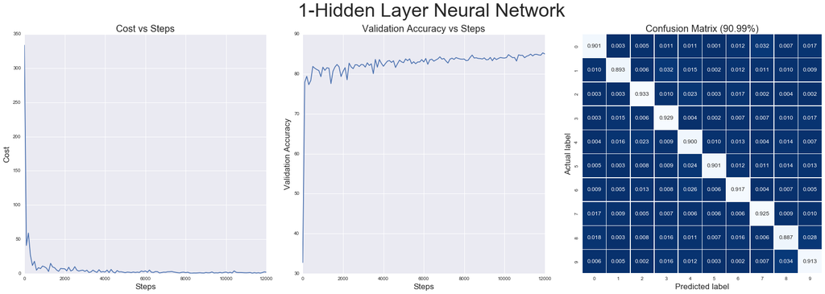

```python
fig, axes = plt.subplots(nrows = 1, ncols = 3, figsize = (30,9));
fig.subplots_adjust(wspace=0.15, hspace=0) # Bringing subplots closer together.
axes[0].plot(step_list, cost_list);
axes[0].set_figure
axes[0].set_title('Cost vs Steps', size = 20);
axes[0].set_xlabel('Steps', size = 17);
axes[0].set_ylabel('Cost', size = 17);
axes[1].plot(step_list, V_accur_list);
axes[1].set_title('Validation Accuracy vs Steps', size = 20);
axes[1].set_xlabel('Steps', size = 17);
axes[1].set_ylabel('Validation Accuracy', size = 17);

# predictions
predicted = [np.argmax(pred[i,:], 0) for i in xrange(0,pred.shape[0])]
#actual
t_labels = [np.where(test_labels[i] == 1)[0][0] for i in xrange(0,pred.shape[0])]

cm = metrics.confusion_matrix(t_labels, predicted)
cm_normalized = cm.astype('float') / cm.sum(axis=1)[:, np.newaxis]
confusion_matrix = pd.DataFrame(data = cm_normalized)
sns.heatmap(confusion_matrix, annot=True, fmt=".3f", linewidths=.5, square = True,ax = axes[2], cmap = 'Blues_r', cbar = False);
axes[2].set_ylabel('Actual label', size = 17);
axes[2].set_xlabel('Predicted label', size = 17);
confusion_title = 'Confusion Matrix ({}%)'.format(test_accuracy)
axes[2].set_title(confusion_title, size = 20);
fig.suptitle('1-Hidden Layer Neural Network', y=1,x = .52, size = 40);
```